# Eksplorativna analiza podataka (Exploratory Data Analysis - EDA) u R-u: Studija slucaja - UN Voting Dataset

Igor Hut

09 January, 2017

## Uvodna razmatranja

- Izvor: *Erik Voeten, “Data and Analyses of Voting in the UN General Assembly”*
- Svi podaci su dostupni u okviru R paketa “unvote”: https://cran.r-project.org/web/packages/unvotes/
- Kao i u GitHub repozitorujumu: https://github.com/dgrtwo/unvotes
- Sadrzani podaci se odnose na istoriju glasanja zemalja clanica na Generalnoj skupstini Ujedinjenih nacija. Date su informacije o datumu glasanja, temi o kojoj se glasalo i kako je svaka od zemalja glasala.

### Setovi podataka

`unvotes` R paket sadrzi tri seta podataka u formi data frame-a (preciznije tbl_df, odn. tibble, sto obezbedjuje bolje formatiranje pri njihovom ispisivanju). Prvi set podataka, `un_votes` se odnosi na istoriju glasanja svake od zemalja. Svaka vrsta sadrzi country/vote par:

```r
library(dplyr)
library(unvotes)
str(un_votes)
```

```
Classes tbl_df, tbl and 'data.frame':   711275 obs. of  3 variables:
 $ rcid   : atomic  3 3 3 3 3 3 3 3 3 3 ...
  ..- attr(*, "comment")= chr "rcid"
 $ country: chr  "Egypt" "Honduras" "Costa Rica" "El Salvador" ...
 $ vote   : Factor w/ 3 levels "abstain","no",..: 1 3 3 3 2 3 3 3 3 3 ...
```

```r
un_votes
```

| rcid | country | vote |
| --- | --- | --- |
| 3 | Egypt | abstain |
| 3 | Honduras | yes |
| 3 | Costa Rica | yes |
| 3 | El Salvador | yes |
| 3 | France | no |
| 3 | Uruguay | yes |
| 3 | Chile | yes |
| 3 | Ecuador | yes |
| 3 | Argentina | yes |
| 3 | Haiti | yes |

[output cut: 990 more lines]

Paket takodje sadrzi i set podataka sa informacijama o svakom javnom glasanju, ukljucujuci datum, opis, i rezoluciju o kojoj je glasano:

```r
un_roll_calls
```

| rcid | session | importantvote | date | unres | amend | para | short | descr |
| --- | --- | --- | --- | --- | --- | --- | --- | --- |
| 3 | 1 | 0 | 1946-01-01 | R/1/66 | 1 | 0 | AMENDMENTS, RULES OF PROCEDURE | TO ADOPT A CUBAN AMENDMENT TO THE UK PROPOSAL REFERRING THE PROVISIONAL RULES OF PROCEDURE AND ANY AMENDMENTS THEREOF TO THE 6TH COMMITTEE, SAID AMENDMENT PRESCRIBING A 1-WEEK TIME LIMIT WITHIN WHICH … |
| 4 | 1 | 0 | 1946-01-02 | R/1/79 | 0 | 0 | SECURITY COUNCIL ELECTIONS | TO ADOPT A USSR PROPOSAL ADJOURNING DEBATE ON AND POSTPONINGELECTIONS OF THE NON-PERMANENT MEMBERS OF THE SECURITY COUNCIL, TO THE FOLLOWING WEEK. |
| 5 | 1 | 0 | 1946-01-04 | R/1/98 | 0 | 0 | VOTING PROCEDURE | TO ADOPT THE KOREAN PROPOSAL THAT INVALID BALLOTS BE INCLUDED IN THE TOTAL NUMBER OF \\MEMBERS PRESENT AND VOTING\\\\, IN CALCULATING THE MAJORITY VOTE.\\"" |
| 6 | 1 | 0 | 1946-01-04 | R/1/107 | 0 | 0 | DECLARATION OF HUMAN RIGHTS | TO ADOPT A CUBAN PROPOSAL (A/3-C) THAT AN ITEM ON A DECLARATION OF THE RIGHTS AND DUTIES OF MAN BE TABLED. |
| 7 | 1 | 0 | 1946-01-02 | R/1/295 | 1 | 0 | GENERAL ASSEMBLY ELECTIONS | TO ADOPT A 6TH COMMITTEE AMENDMENT (A/14) TO THE PROVISIONAL RULES OF PROCEDURE, WHICH AMENDMENT PROVIDES THAT RULE 73 SHOULD END WITH:\\THERE SHALL BE NO NOMINATIONS.\\\\"\t0\t0\t0\t0\t0\t0 |
| 8 | 1 | 0 | 1946-01-05 | R/1/297 | 1 | 0 | ECOSOC POWERS | TO ADOPT A SECOND 6TH COMM. AMENDMENT (A/14) TO THE PROVISIONAL RULES OF PROCEDURE, WHICH AMENDMENT EPLACES PROVISIONAL RULE T WITH A NEW TEXT AUTHORIZING THE ECONOMIC & SOC. COUNCIL TO CALL INTERNATI… |
| 9 | 1 | 0 | 1946-02-05 | R/1/329 | 0 | 0 | POST-WAR RECONSTRUCTION | TO OPEN THE DISCUSSION ON THE POLISH DRAFT RESOLUTION (A/22) PROVIDING FOR ECO. & SOC. COUNCIL STUDY AND ASSEMBLY DISCUSSION OF THE RECONSTRUCTION OF U.N. MEMBER-COUNTRIES DEVASTATED BY THE WAR. |
| 10 | 1 | 0 | 1946-02-05 | R/1/361 | 1 | 1 | U.N. MEMBERS, RELATIONS WITH SPAIN | TO ADOPT GENERAL COMM. DRAFT RESOLUTION (A/40) AS AMENDED BY A NORWEGIAN ORAL PROPOSAL (REPLACING \\TAKE INTO ACCOUNT THE LETTER AND SPIRIT\\\\ IN 3RD PARAGRAPH WITH, \\\\"ACT IN ACCORDANCE WITH THE L… |
| 11 | 1 | 0 | 1946-02-05 | R/1/376 | 0 | 0 | TRUSTEESHIP AMENDMENTS | TO ADOPT DRAFT RESOLUTIONS I AND II AS A WHOLE, OF THE 4TH COMM. REPORT (A/34) ON NON-SELF-GOVERNING TERRITORIES. RESOLUTION I PROVIDES TO PROMOTE THE POLITICAL, SOCIAL, ECONOMIC, AND EDUCATIONAL ASPI… |
| 12 | 1 | 0 | 1946-02-06 | R/1/394 | 1 | 1 | COUNCIL MEMBER TERM LENGTH | TO ADOPT PARAGRAPH (A) OF THE 6TH COMM. DRAFT RESOLUTION A/38) ON TERMS OF OFFICE OF MEMBERS OF UN COUNCILS, WHICH PARAGRAPH AMENDS PROVISIONAL RULE 78 BY BEGINNING THE TERM OF OFFICE IMMEDIATELY UPON… |

[output cut: 990 more lines]

Konacno `un_roll_call_issues` set podataka sadrzi informacije o medjusobnoj povezanosti razlicitih glasanja kao i o 6 generalnih problema o kojima je glasano u Gen. skupstini UN-a:

```r
un_roll_call_issues
```

| rcid | short_name | issue |
| --- | --- | --- |
| 30 | me | Palestinian conflict |
| 34 | me | Palestinian conflict |
| 77 | me | Palestinian conflict |
| 9002 | me | Palestinian conflict |
| 9003 | me | Palestinian conflict |
| 9004 | me | Palestinian conflict |
| 9005 | me | Palestinian conflict |
| 9006 | me | Palestinian conflict |
| 128 | me | Palestinian conflict |
| 129 | me | Palestinian conflict |

[output cut: 990 more lines]

```r
count(un_roll_call_issues, issue, sort = TRUE)
```

| issue | n |
| --- | --- |
| Palestinian conflict | 1047 |
| Colonialism | 971 |
| Human rights | 901 |
| Arms control and disarmament | 859 |
| Nuclear weapons and nuclear material | 712 |
| Economic development | 461 |

Za vise informacija o svakom od pojedinacnih setova podataka koristite naredbu `help()`.

## Priprema podataka za analizu

Za pocetak cemo da izvrsimo “inner join” za setove `un_votes` i `un_roll_calls` a na osnovu zajednicke kolone `rcid`. Na ovaj nacin dobijamo objedinjen set podataka sa vecinom informacija relevantnih za dalju eksplorativnu analizu.

```r
joined <- inner_join(un_votes, un_roll_calls, by = "rcid")
joined
```

| rcid | country | vote | session | importantvote | date | unres | amend | para | short | descr |
| --- | --- | --- | --- | --- | --- | --- | --- | --- | --- | --- |
| 3 | Egypt | abstain | 1 | 0 | 1946-01-01 | R/1/66 | 1 | 0 | AMENDMENTS, RULES OF PROCEDURE | TO ADOPT A CUBAN AMENDMENT TO THE UK PROPOSAL REFERRING THE PROVISIONAL RULES OF PROCEDURE AND ANY AMENDMENTS THEREOF TO THE 6TH COMMITTEE, SAID AMENDMENT PRESCRIBING A 1-WEEK TIME LIMIT WITHIN WHICH … |
| 3 | Honduras | yes | 1 | 0 | 1946-01-01 | R/1/66 | 1 | 0 | AMENDMENTS, RULES OF PROCEDURE | TO ADOPT A CUBAN AMENDMENT TO THE UK PROPOSAL REFERRING THE PROVISIONAL RULES OF PROCEDURE AND ANY AMENDMENTS THEREOF TO THE 6TH COMMITTEE, SAID AMENDMENT PRESCRIBING A 1-WEEK TIME LIMIT WITHIN WHICH … |
| 3 | Costa Rica | yes | 1 | 0 | 1946-01-01 | R/1/66 | 1 | 0 | AMENDMENTS, RULES OF PROCEDURE | TO ADOPT A CUBAN AMENDMENT TO THE UK PROPOSAL REFERRING THE PROVISIONAL RULES OF PROCEDURE AND ANY AMENDMENTS THEREOF TO THE 6TH COMMITTEE, SAID AMENDMENT PRESCRIBING A 1-WEEK TIME LIMIT WITHIN WHICH … |
| 3 | El Salvador | yes | 1 | 0 | 1946-01-01 | R/1/66 | 1 | 0 | AMENDMENTS, RULES OF PROCEDURE | TO ADOPT A CUBAN AMENDMENT TO THE UK PROPOSAL REFERRING THE PROVISIONAL RULES OF PROCEDURE AND ANY AMENDMENTS THEREOF TO THE 6TH COMMITTEE, SAID AMENDMENT PRESCRIBING A 1-WEEK TIME LIMIT WITHIN WHICH … |
| 3 | France | no | 1 | 0 | 1946-01-01 | R/1/66 | 1 | 0 | AMENDMENTS, RULES OF PROCEDURE | TO ADOPT A CUBAN AMENDMENT TO THE UK PROPOSAL REFERRING THE PROVISIONAL RULES OF PROCEDURE AND ANY AMENDMENTS THEREOF TO THE 6TH COMMITTEE, SAID AMENDMENT PRESCRIBING A 1-WEEK TIME LIMIT WITHIN WHICH … |
| 3 | Uruguay | yes | 1 | 0 | 1946-01-01 | R/1/66 | 1 | 0 | AMENDMENTS, RULES OF PROCEDURE | TO ADOPT A CUBAN AMENDMENT TO THE UK PROPOSAL REFERRING THE PROVISIONAL RULES OF PROCEDURE AND ANY AMENDMENTS THEREOF TO THE 6TH COMMITTEE, SAID AMENDMENT PRESCRIBING A 1-WEEK TIME LIMIT WITHIN WHICH … |
| 3 | Chile | yes | 1 | 0 | 1946-01-01 | R/1/66 | 1 | 0 | AMENDMENTS, RULES OF PROCEDURE | TO ADOPT A CUBAN AMENDMENT TO THE UK PROPOSAL REFERRING THE PROVISIONAL RULES OF PROCEDURE AND ANY AMENDMENTS THEREOF TO THE 6TH COMMITTEE, SAID AMENDMENT PRESCRIBING A 1-WEEK TIME LIMIT WITHIN WHICH … |
| 3 | Ecuador | yes | 1 | 0 | 1946-01-01 | R/1/66 | 1 | 0 | AMENDMENTS, RULES OF PROCEDURE | TO ADOPT A CUBAN AMENDMENT TO THE UK PROPOSAL REFERRING THE PROVISIONAL RULES OF PROCEDURE AND ANY AMENDMENTS THEREOF TO THE 6TH COMMITTEE, SAID AMENDMENT PRESCRIBING A 1-WEEK TIME LIMIT WITHIN WHICH … |
| 3 | Argentina | yes | 1 | 0 | 1946-01-01 | R/1/66 | 1 | 0 | AMENDMENTS, RULES OF PROCEDURE | TO ADOPT A CUBAN AMENDMENT TO THE UK PROPOSAL REFERRING THE PROVISIONAL RULES OF PROCEDURE AND ANY AMENDMENTS THEREOF TO THE 6TH COMMITTEE, SAID AMENDMENT PRESCRIBING A 1-WEEK TIME LIMIT WITHIN WHICH … |
| 3 | Haiti | yes | 1 | 0 | 1946-01-01 | R/1/66 | 1 | 0 | AMENDMENTS, RULES OF PROCEDURE | TO ADOPT A CUBAN AMENDMENT TO THE UK PROPOSAL REFERRING THE PROVISIONAL RULES OF PROCEDURE AND ANY AMENDMENTS THEREOF TO THE 6TH COMMITTEE, SAID AMENDMENT PRESCRIBING A 1-WEEK TIME LIMIT WITHIN WHICH … |

[output cut: 990 more lines]

## Eksplorativna analiza

#### Koliko ukupno ima glasova, za sva glasanja i sve godine, i koliko je procentualno bilo glasova “za” u odnosu na ukupan broj glasova?

```r
summarise(joined, total = n(), percent_yes = mean(vote == "yes"))
```

| total | percent_yes |
| --- | --- |
| 711275 | 0.7963952 |

#### Kako su glasale pojedinacne zemlje, u proseku, tokom istorije Gen. skupstine UN?

```r
by_country <- joined %>%
    group_by(country) %>%
    summarise(n_votes = n(),
            percent_yes = mean(vote == "yes"))
# Print the by_country dataset
by_country
```

| country | n_votes | percent_yes |
| --- | --- | --- |
| Afghanistan | 4824 | 0.8381012 |
| Albania | 3363 | 0.7204877 |
| Algeria | 4374 | 0.8978052 |
| Andorra | 1410 | 0.6510638 |
| Angola | 2950 | 0.9223729 |
| Antigua and Barbuda | 2521 | 0.9170964 |
| Argentina | 5207 | 0.7743422 |
| Armenia | 1479 | 0.7592968 |
| Australia | 5245 | 0.5542421 |
| Austria | 4786 | 0.6320518 |

[output cut: 190 more lines]

```r
arrange(by_country, percent_yes)
```

| country | n_votes | percent_yes |
| --- | --- | --- |
| Zanzibar | 2 | 0.0000000 |
| United States | 5237 | 0.2850869 |
| Palau | 777 | 0.3063063 |
| Israel | 4790 | 0.3503132 |
| Federal Republic of Germany | 2151 | 0.3984193 |
| Micronesia, Federated States of | 1341 | 0.4131245 |
| United Kingdom | 5218 | 0.4269835 |
| France | 5171 | 0.4320248 |
| Marshall Islands | 1468 | 0.4788828 |
| Belgium | 5238 | 0.4925544 |

[output cut: 190 more lines]

```r
arrange(by_country, desc(percent_yes))
```

| country | n_votes | percent_yes |
| --- | --- | --- |
| Seychelles | 1698 | 0.9770318 |
| Timor-Leste | 697 | 0.9670014 |
| Sao Tome and Principe | 2329 | 0.9665092 |
| Djibouti | 3193 | 0.9564673 |
| Guinea-Bissau | 2933 | 0.9546539 |
| Comoros | 2435 | 0.9462012 |
| Cabo Verde | 3153 | 0.9454488 |
| Mozambique | 3306 | 0.9431337 |
| Yemen | 1527 | 0.9423707 |
| Zimbabwe | 2766 | 0.9421547 |

[output cut: 190 more lines]

```r
arrange(by_country, n_votes)
```

| country | n_votes | percent_yes |
| --- | --- | --- |
| Zanzibar | 2 | 0.0000000 |
| Kiribati | 93 | 0.8172043 |
| South Sudan | 96 | 0.6979167 |
| Montenegro | 558 | 0.6433692 |
| Tuvalu | 576 | 0.8246528 |
| Nauru | 606 | 0.6089109 |
| Timor-Leste | 697 | 0.9670014 |
| Tonga | 775 | 0.7303226 |
| Palau | 777 | 0.3063063 |
| Switzerland | 857 | 0.6569428 |

[output cut: 190 more lines]

Moze se primetiti da ima nekoliko zemalja koje su znacajno manje puta ucestvovale u glasanju od ostalih (Zanzibar, Kiribati, South Sudan). Ove zemlje i podatke vezane za njih cemo izostatiti iz buduce analize. Filterujemo set podataka tako da izostavimo sve zemlje koje su glasale manje od 100 puta:

```r
by_country %>%
filter( n_votes > 100) %>%
  arrange(percent_yes)
```

| country | n_votes | percent_yes |
| --- | --- | --- |
| United States | 5237 | 0.2850869 |
| Palau | 777 | 0.3063063 |
| Israel | 4790 | 0.3503132 |
| Federal Republic of Germany | 2151 | 0.3984193 |
| Micronesia, Federated States of | 1341 | 0.4131245 |
| United Kingdom | 5218 | 0.4269835 |
| France | 5171 | 0.4320248 |
| Marshall Islands | 1468 | 0.4788828 |
| Belgium | 5238 | 0.4925544 |
| Luxembourg | 5169 | 0.5105436 |

[output cut: 187 more lines]

#### Kako se menjao generalni trend glasanja kroz istoriju?

```r
library(lubridate)
by_year <- joined %>%
  group_by(year = year(date)) %>%
  summarize(n_votes = n(),
            percent_yes = mean(vote == "yes")) %>%
  filter( n_votes > 100)
by_year
```

| year | n_votes | percent_yes |
| --- | --- | --- |
| 1946 | 2143 | 0.5734951 |
| 1947 | 2039 | 0.5693968 |
| 1948 | 3454 | 0.3998263 |
| 1949 | 5700 | 0.4254386 |
| 1950 | 2911 | 0.4970800 |
| 1951 | 402 | 0.6567164 |
| 1952 | 4082 | 0.5460559 |
| 1953 | 1537 | 0.6317502 |
| 1954 | 1788 | 0.6224832 |
| 1955 | 2169 | 0.6947902 |

[output cut: 58 more lines]

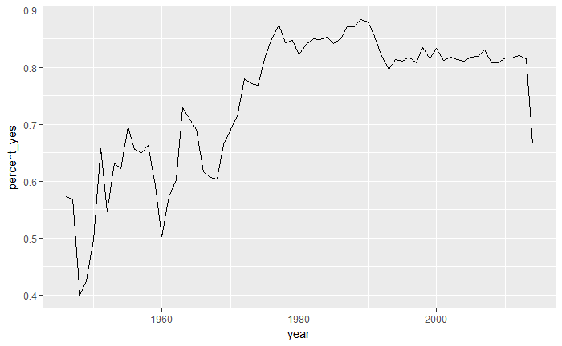

```r
# Da vizualizujemo ovaj trend pomocu linijskog grafika
library(ggplot2)
ggplot(by_year, aes(x = year, y = percent_yes)) +
  geom_line()
```

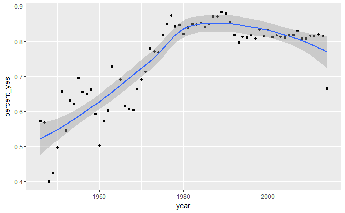

```r
# Scatter plot + geom_smooth
ggplot(by_year, aes( year, percent_yes)) +
  geom_point() +
  geom_smooth()
```

Zanimljiv trend. Neposredno nakon nakon zavrsetka Drugog svetskog rata su evidentno postojale ostre nesuglasice po mnogim pitanjima. U periodu od 80-tih godina proslog veka, pa sve do skoro, deluje kao da je postojao, gotovo, koncenzus po mnogim pitanjima, medju vecinom clanica Gen. skupstine UN.

#### Koliko cesto je svaka od zemalja glasala “za” po godinama?

```r
library(lubridate)
by_year_country <- joined %>%
  group_by( year = year(date), country) %>%
  summarise(n_votes = n(), percent_yes = mean(vote == "yes"))
by_year_country
```

| year | country | n_votes | percent_yes |
| --- | --- | --- | --- |
| 1946 | Afghanistan | 17 | 0.4117647 |
| 1946 | Argentina | 43 | 0.6976744 |
| 1946 | Australia | 43 | 0.5581395 |
| 1946 | Belarus | 43 | 0.4418605 |
| 1946 | Belgium | 43 | 0.6046512 |
| 1946 | Bolivia, Plurinational State of | 43 | 0.6976744 |
| 1946 | Brazil | 43 | 0.6046512 |
| 1946 | Canada | 42 | 0.6428571 |
| 1946 | Chile | 43 | 0.6046512 |
| 1946 | Colombia | 42 | 0.3095238 |

[output cut: 990 more lines]

#### Kako su kroz istoriju glasale, SAD, SSSR, Rusija, Jugoslavija, Srbija i Hrvatska?

Proverimo prvo da li ima svih ovih zemalja u setu:

```r
country <- distinct(by_country, country) %>%
  arrange(country)
View(country)
inner_join(country, data.frame(country = c("Serbia", "Croatia", "United States", "Russian Federation", "Yugoslavia", "Soviet Union")))
```

```
joining character vector and factor, coercing into character vector
```

| country |
| --- |
| Croatia |
| Russian Federation |
| United States |
| Yugoslavia |

Izgleda da nema ni Srbije ni SSSR-a. Posmatracemo Jugoslaviju, Rusiju, Hrvatsku i SAD:

```r
filt_countries <- filter(by_year_country, country %in% c("Croatia", "United States", "Russian Federation", "Yugoslavia"))
filt_countries
```

| year | country | n_votes | percent_yes |
| --- | --- | --- | --- |
| 1946 | Russian Federation | 43 | 0.44186047 |
| 1946 | United States | 43 | 0.60465116 |
| 1946 | Yugoslavia | 41 | 0.46341463 |
| 1947 | Russian Federation | 38 | 0.52631579 |
| 1947 | United States | 38 | 0.71052632 |
| 1947 | Yugoslavia | 38 | 0.50000000 |
| 1948 | Russian Federation | 64 | 0.53125000 |
| 1948 | United States | 64 | 0.39062500 |
| 1948 | Yugoslavia | 64 | 0.53125000 |
| 1949 | Russian Federation | 103 | 0.64077670 |

[output cut: 210 more lines]

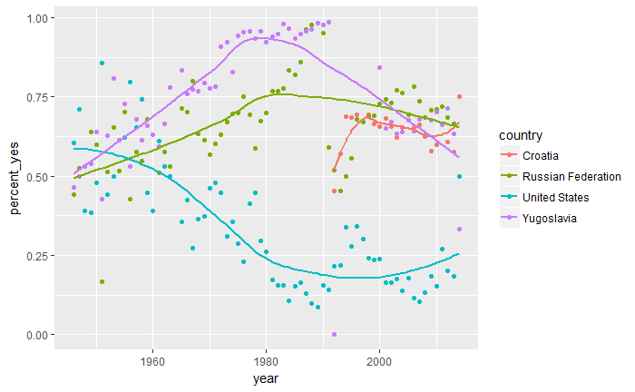

```r
ggplot(filt_countries, aes(x = year, y = percent_yes, col = country)) +
  geom_point() +
  geom_smooth(se = FALSE)
```

**Evidentno da su opservacije za Srbiju, Srbiju i Crnu Goru i Jugoslavuju deklarisane kao “Yugoslavia” a za Rusiju i SSSR kao “Russian Federation”. Zanimljivo, a donekle i ocekivano, generalni trend glasanja Ruske Federacije i Jugoslavije/ Srbije su prilicno pozitivno korelisani tokom istorije, dok je situacija sa SAD upravo suprotna. Zarad podrobnije komparacije tokom poslednje dve decenije posmatracemo samo period od 1990-te do 2014-te godine.**

```r
# Samo da jos jednom proverimo raspone vrednosti, pre svega za var. "year"
summary(filt_countries)
```

```
      year        country             n_votes        percent_yes
 Min.   :1946   Length:220         Min.   :  2.00   Min.   :0.0000
 1st Qu.:1965   Class :character   1st Qu.: 54.00   1st Qu.:0.4455
 Median :1983   Mode  :character   Median : 70.00   Median :0.6317
 Mean   :1982                      Mean   : 75.39   Mean   :0.5812
 3rd Qu.:2001                      3rd Qu.: 89.00   3rd Qu.:0.7159
 Max.   :2014                      Max.   :160.00   Max.   :0.9865
```

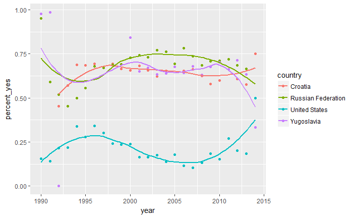

```r
ggplot(filt_countries, aes(x = year, y = percent_yes, col = country)) +
  geom_point() +
  geom_smooth(se = FALSE) +
  scale_x_continuous(limits = c(1990, 2014))
```

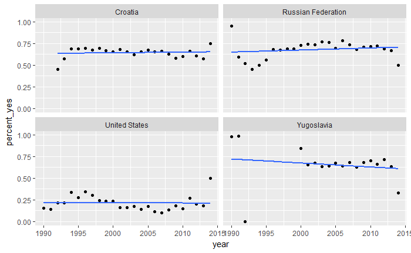

```r
ggplot(filt_countries, aes(x = year, y = percent_yes)) +
  geom_point() +
  geom_smooth(method = "lm", se = FALSE) +
  scale_x_continuous(limits = c(1990, 2014)) +
  facet_wrap( ~ country)
```

#### Kako je svaka od izabranih zemalja glasala tokom vremena o generalnim problemima sadrzanim u `un_roll_call_issues?

Prvo da proverimo o kojim se problemima tacno radi:

```r
distinct(un_roll_call_issues, issue)
```

| issue |
| --- |
| Palestinian conflict |
| Nuclear weapons and nuclear material |
| Arms control and disarmament |
| Human rights |
| Colonialism |
| Economic development |

Nazalost u ovom setu nema podataka o glasanjima koja su se direktno ticala politickih desavanaja na prostoru bivse Jugoslavije, sto bi nama bilo posebno zanimljivo. Elem, nastavimo sa analizom:

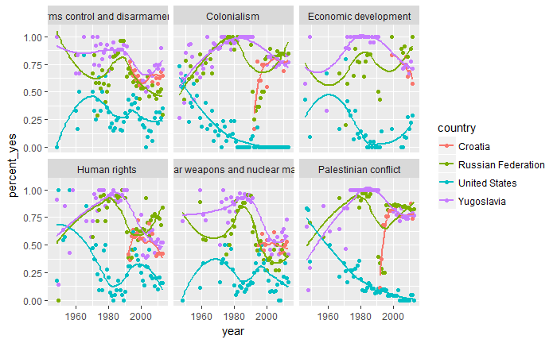

```r
joined %>%
  filter(country %in% c("Croatia", "United States", "Russian Federation", "Yugoslavia")) %>%
  inner_join(un_roll_call_issues, by = "rcid") %>%
  group_by(year = year(date), country, issue) %>%
  summarize(votes = n(),
            percent_yes = mean(vote == "yes")) %>%
  filter(votes > 5) %>%
  ggplot(aes(year, percent_yes, col = country)) +
  geom_point() +
  geom_smooth(se = FALSE) +
  facet_wrap(~ issue)
```

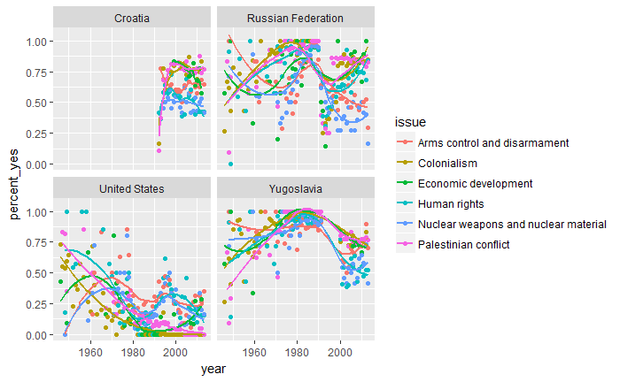

```r
#Da probamo i sa drugacijim rasporedom
joined %>%
  filter(country %in% c("Croatia", "United States", "Russian Federation", "Yugoslavia")) %>%
  inner_join(un_roll_call_issues, by = "rcid") %>%
  group_by(year = year(date), country, issue) %>%
  summarize(votes = n(),
            percent_yes = mean(vote == "yes")) %>%
  filter(votes > 5) %>%
  ggplot(aes(year, percent_yes, col = issue)) +
  geom_point() +
  geom_smooth(se = FALSE) +
  facet_wrap(~ country)
```